# Analisi dei fattori che influenzano il valore di mercato dei calciatori nei cinque principali campionati europei

## Introduzione

Ho scelto questo argomento perché seguo e gioco a calcio e conosco molto bene **Transfermarkt** dove sono presenti anche dati relativi al mio profilo, rendendo il progetto ancora più personale.

[figure not shown]

## Obiettivo dello studio

L'obiettivo del progetto è capire quali caratteristiche sono maggiormente associate al valore di mercato dei calciatori.

**Domanda principale**

Quali fattori influenzano maggiormente il valore di mercato dei giocatori dei cinque principali campionati europei?

L'analisi considera:

- campionato
- ruolo
- età

## Dataset utilizzato

Per questo progetto sono stati utilizzati dati pubblici provenienti da **Transfermarkt**, una delle principali piattaforme dedicate al calcio professionistico.

- **players.csv**: informazioni anagrafiche e tecniche dei giocatori;

**Fonte**: David Cariboo, Football Data from Transfermarkt (Kaggle)

**Disponibile online**: Kaggle

**Link**: https://www.kaggle.com/datasets/davidcariboo/player-scores/data

## Dataset finale

Al termine della fase di preparazione è stato ottenuto un dataset contenente esclusivamente i calciatori appartenenti ai cinque principali campionati europei e dotati di un valore di mercato disponibile. Il dataset finale costituisce la base per tutte le analisi successive.

**Campione finale**

Giocatori analizzati: 10735

Campionati analizzati: 5

# Domanda 1

## Com'è composto il campione analizzato?

Prima di analizzare il valore di mercato è utile comprendere come è distribuito il campione tra i cinque principali campionati europei.

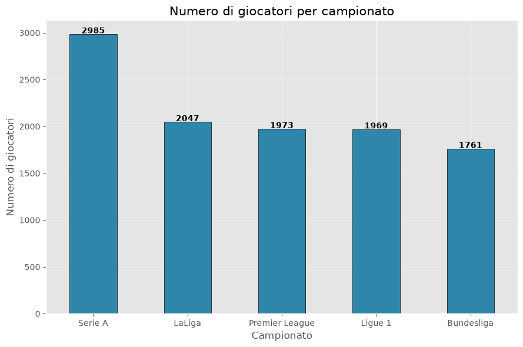

### Interpretazione

La presenza di un numero elevato di osservazioni per ciascun campionato rende il campione adeguato per le analisi successive.

# Domanda 2

## Il campionato influenza il valore di mercato dei calciatori?

Questa analisi permette di capire se alcuni campionati concentrano mediamente giocatori con valutazioni economiche più elevate rispetto ad altri.

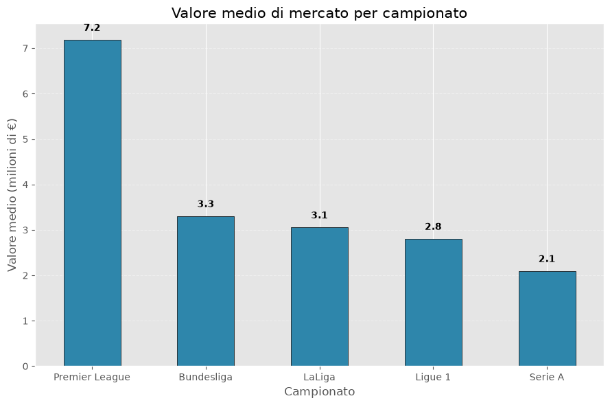

### Interpretazione

La Premier League presenta il valore medio più elevato, mentre la Serie A quello più basso.

# Domanda 3

## Il ruolo influenza il valore di mercato?

Per confrontare il valore di mercato tra i diversi ruoli sono stati considerati tutti i calciatori appartenenti ai cinque principali campionati europei.

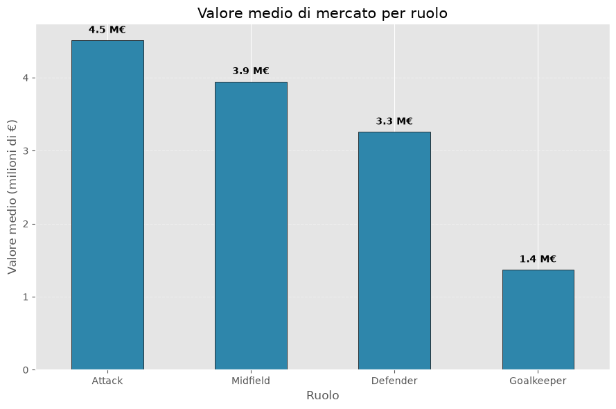

### Interpretazione

Gli attaccanti presentano il valore medio più alto, mentre i portieri quello più basso.

# Domanda 4

## Il valore di mercato varia in base all'età?

I calciatori vengono suddivisi in fasce di età e viene calcolato il valore medio di mercato per ciascuna fascia.

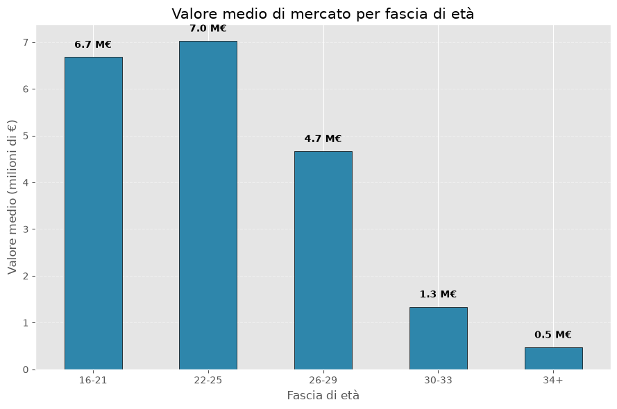

### Interpretazione

Il grafico mostra come i valori di mercato più alti si verfiicano nella fascia di età tra i 16-25 anni.

# Conclusioni

L’obiettivo del progetto era individuare quali caratteristiche influenzano il valore di mercato dei calciatori dei cinque principali campionati europei.

Dalle analisi sono emersi questi risultati:

- il valore di mercato varia tra i diversi campionati;
- il ruolo del calciatore influisce sul valore di mercato;
- l’età rappresenta un fattore importante;

In conclusione, il valore di mercato dipende dalla combinazione di età, ruolo e dal campionato in cui si gioca . L’analisi dei dati permette quindi di individuare i principali fattori associati al valore economico dei calciatori